# bike

# Introduction

Extract from Kaggle: Bike sharing systems are a means of renting bicycles where the process of obtaining membership, rental, and bike return is automated via a network of kiosk locations throughout a city. Using these systems, people are able rent a bike from a one location and return it to a different place on an as-needed basis. Currently, there are over 500 bike-sharing programs around the world.

The data generated by these systems makes them attractive for researchers because the duration of travel, departure location, arrival location, and time elapsed is explicitly recorded. Bike sharing systems therefore function as a sensor network, which can be used for studying mobility in a city. In this competition, participants are asked to combine historical usage patterns with weather data in order to forecast bike rental demand in the Capital Bikeshare program in Washington, D.C.

Goal: Predict the total number of bikes rented per each hour on the 20th day, given the data from the preceeding days.

# Reading and preparing the data

We begin by importing the necessary modules and reading the data.

```python
%matplotlib inline
import pandas as pd
import numpy as np
import matplotlib.pyplot as plt
import seaborn as sns
import missingno as msno
import datetime
import calendar
import math
sns.set_style('darkgrid')
```

```python
df = pd.read_csv("train.csv")
df.head()
```

|  | datetime | season | holiday | workingday | weather | temp | atemp | humidity | windspeed | casual | registered | count |
| --- | --- | --- | --- | --- | --- | --- | --- | --- | --- | --- | --- | --- |
| 0 | 2011-01-01 00:00:00 | 1 | 0 | 0 | 1 | 9.84 | 14.395 | 81 | 0.0 | 3 | 13 | 16 |
| 1 | 2011-01-01 01:00:00 | 1 | 0 | 0 | 1 | 9.02 | 13.635 | 80 | 0.0 | 8 | 32 | 40 |
| 2 | 2011-01-01 02:00:00 | 1 | 0 | 0 | 1 | 9.02 | 13.635 | 80 | 0.0 | 5 | 27 | 32 |
| 3 | 2011-01-01 03:00:00 | 1 | 0 | 0 | 1 | 9.84 | 14.395 | 75 | 0.0 | 3 | 10 | 13 |
| 4 | 2011-01-01 04:00:00 | 1 | 0 | 0 | 1 | 9.84 | 14.395 | 75 | 0.0 | 0 | 1 | 1 |

### Description of each feature (12 in total)

- datetime - hourly date + timestamp
- season - 1 = spring, 2 = summer, 3 = fall, 4 = winter
- holiday - whether the day is considered a holiday
- workingday - whether the day is neither a weekend nor holiday
- weather -
- 1: Clear, Few clouds, Partly cloudy, Partly cloudy
- 2: Mist + Cloudy, Mist + Broken clouds, Mist + Few clouds, Mist
- 3: Light Snow, Light Rain + Thunderstorm + Scattered clouds, Light Rain + Scattered clouds
- 4: Heavy Rain + Ice Pallets + Thunderstorm + Mist, Snow + Fog
- temp - temperature in Celsius
- atemp - "feels like" temperature in Celsius
- humidity - relative humidity
- windspeed - wind speed
- casual - number of non-registered user rentals initiated
- registered - number of registered user rentals initiated
- count - number of total rentals

### Feature Engineering

```python
df.dtypes
```

```
datetime       object
season          int64
holiday         int64
workingday      int64
weather         int64
temp          float64
atemp         float64
humidity        int64
windspeed     float64
casual          int64
registered      int64
count           int64
dtype: object
```

Notice how datetime is an object. Let's first convert it to a datetime64 data type so we can split it into weekday, hour, month and year.

```python
df['datetime'] = pd.to_datetime(df['datetime'])
df.dtypes
```

```
datetime      datetime64[ns]
season                 int64
holiday                int64
workingday             int64
weather                int64
temp                 float64
atemp                float64
humidity               int64
windspeed            float64
casual                 int64
registered             int64
count                  int64
dtype: object
```

```python
df_time = pd.DataFrame({'year':df['datetime'].dt.year,'month':df['datetime'].dt.month,'day':df['datetime'].dt.weekday,'hour':df['datetime'].dt.hour})
# 0 - Monday, 6 - Sunday
df = pd.concat([df['datetime'],df_time,df[['season','holiday','workingday','weather','temp','atemp','humidity','windspeed','casual','registered','count']]], axis=1)
df.head()
```

|  | datetime | year | month | day | hour | season | holiday | workingday | weather | temp | atemp | humidity | windspeed | casual | registered | count |
| --- | --- | --- | --- | --- | --- | --- | --- | --- | --- | --- | --- | --- | --- | --- | --- | --- |
| 0 | 2011-01-01 00:00:00 | 2011 | 1 | 5 | 0 | 1 | 0 | 0 | 1 | 9.84 | 14.395 | 81 | 0.0 | 3 | 13 | 16 |
| 1 | 2011-01-01 01:00:00 | 2011 | 1 | 5 | 1 | 1 | 0 | 0 | 1 | 9.02 | 13.635 | 80 | 0.0 | 8 | 32 | 40 |
| 2 | 2011-01-01 02:00:00 | 2011 | 1 | 5 | 2 | 1 | 0 | 0 | 1 | 9.02 | 13.635 | 80 | 0.0 | 5 | 27 | 32 |
| 3 | 2011-01-01 03:00:00 | 2011 | 1 | 5 | 3 | 1 | 0 | 0 | 1 | 9.84 | 14.395 | 75 | 0.0 | 3 | 10 | 13 |
| 4 | 2011-01-01 04:00:00 | 2011 | 1 | 5 | 4 | 1 | 0 | 0 | 1 | 9.84 | 14.395 | 75 | 0.0 | 0 | 1 | 1 |

We will also map some of the categorical features, which helps in visualisation.

```python
df['season'] = df.season.map({1: 'Spring', 2 : 'Summer', 3 : 'Fall', 4 :'Winter' })
df['day'] = df.day.map({0: 'Monday', 1: 'Tuesday', 2: 'Wednesday', 3: 'Thursday', 4: 'Friday', 5: 'Saturday', 6: 'Sunday'})
```

Next, we categorise the variables.

```python
categorisedVars = ['day','hour','month','year','season','holiday','workingday','weather']
for var in categorisedVars:
    df[var] = df[var].astype('category')
```

Now we look at a summary of each features.

```python
df.describe()
```

|  | temp | atemp | humidity | windspeed | casual | registered | count |
| --- | --- | --- | --- | --- | --- | --- | --- |
| count | 10886.00000 | 10886.000000 | 10886.000000 | 10886.000000 | 10886.000000 | 10886.000000 | 10886.000000 |
| mean | 20.23086 | 23.655084 | 61.886460 | 12.799395 | 36.021955 | 155.552177 | 191.574132 |
| std | 7.79159 | 8.474601 | 19.245033 | 8.164537 | 49.960477 | 151.039033 | 181.144454 |
| min | 0.82000 | 0.760000 | 0.000000 | 0.000000 | 0.000000 | 0.000000 | 1.000000 |
| 25% | 13.94000 | 16.665000 | 47.000000 | 7.001500 | 4.000000 | 36.000000 | 42.000000 |
| 50% | 20.50000 | 24.240000 | 62.000000 | 12.998000 | 17.000000 | 118.000000 | 145.000000 |
| 75% | 26.24000 | 31.060000 | 77.000000 | 16.997900 | 49.000000 | 222.000000 | 284.000000 |
| max | 41.00000 | 45.455000 | 100.000000 | 56.996900 | 367.000000 | 886.000000 | 977.000000 |

Since the counts for each feature are equal, we can conclude there are no missing values. We can also use a useful module called missingno to verify this.

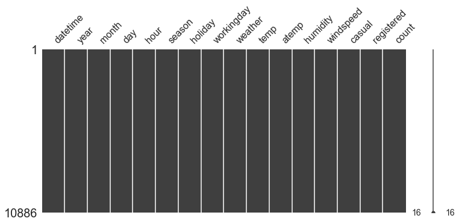

```python
msno.matrix(df,figsize=(12,5))
```

# Exploratory Data Analysis

### Outlier Analysis

Since we are predicting a continuous variable, it is useful for us to check for outliers.

[output not shown]

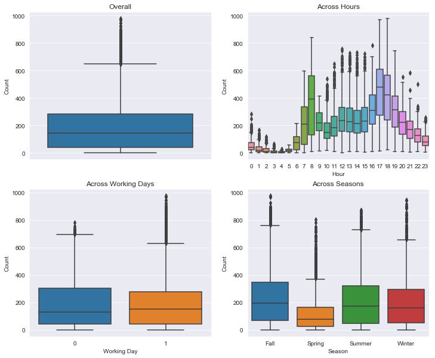

```python
fig,axes = plt.subplots(nrows=2,ncols=2)
fig.set_size_inches(12,10)
# Plots
sns.boxplot(data = df, y = 'count', orient='v', ax = axes[0][0])
sns.boxplot(data = df, y = 'count', x = 'hour', ax = axes[0][1])
sns.boxplot(data = df, y = 'count', x = 'workingday', ax = axes[1][0])
sns.boxplot(data = df, y = 'count', x = 'season', ax = axes[1][1])
# Labelling
axes[0][0].set(ylabel='Count',title='Overall')
axes[0][1].set(xlabel='Hour', ylabel='Count',title='Across Hours')
axes[1][0].set(xlabel='Working Day', ylabel='Count',title='Across Working Days')
axes[1][1].set(xlabel='Season', ylabel='Count',title='Across Seasons')
```

All of the above helps to explain the the high number of outliers above the outer quartile limit in the overall count.

Let's take a closer look at the overall count.

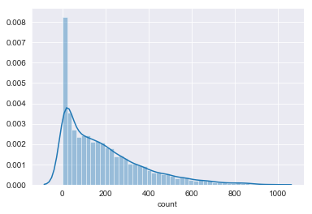

```python
sns.distplot(df['count'])
```

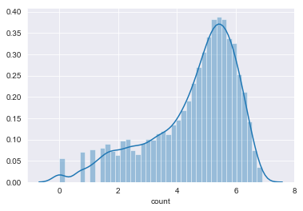

```python
sns.distplot(df['count'].apply(np.log))
```

By Chebyshev's Rule, let us also remove entries that lie outside of 3 standard deviations from the mean.

```python
df_withoutoutliers = df[np.abs(df["count"]-df["count"].mean())<=(3*df["count"].std())]
df.shape
```

```
(10886, 16)
```

```python
df_withoutoutliers.shape
```

```
(10739, 16)
```

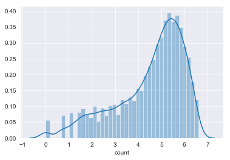

```python
sns.distplot(df_withoutoutliers['count'].apply(np.log))
```

### Correlation Matrix

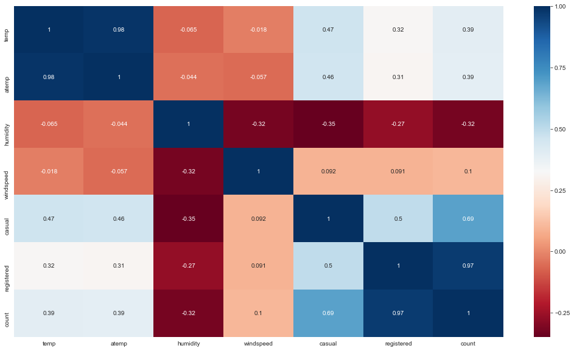

```python
colormap = plt.cm.RdBu
fig,ax = plt.subplots()
fig.set_size_inches(18,10)
sns.heatmap(df.corr(),cmap=colormap, annot = True)
plt.show()
```

We observe the following:

- temp and atemp have strong positive correlation (almost 1). We can consider including just one of them in our predictive model
- windspeed has low positive correlation with count, we can consider removing it from the regression model
- While casual and registered have strong positive correlation with count, they are leakage variables which will not be included in our regression model

We will look into these features in greater detail.

### Univariate Plots

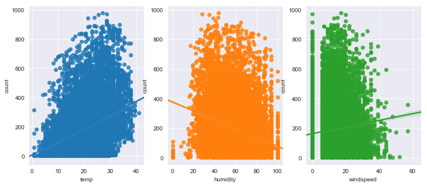

```python
fig,(ax1,ax2,ax3) = plt.subplots(ncols=3)
fig.set_size_inches(12,5)
sns.regplot(x = 'temp', y = 'count', data = df, ax = ax1)
sns.regplot(x = 'humidity', y = 'count', data = df, ax = ax2)
sns.regplot(x = 'windspeed', y = 'count', data = df, ax = ax3)
```

We will also compare average count across months:

[output not shown]

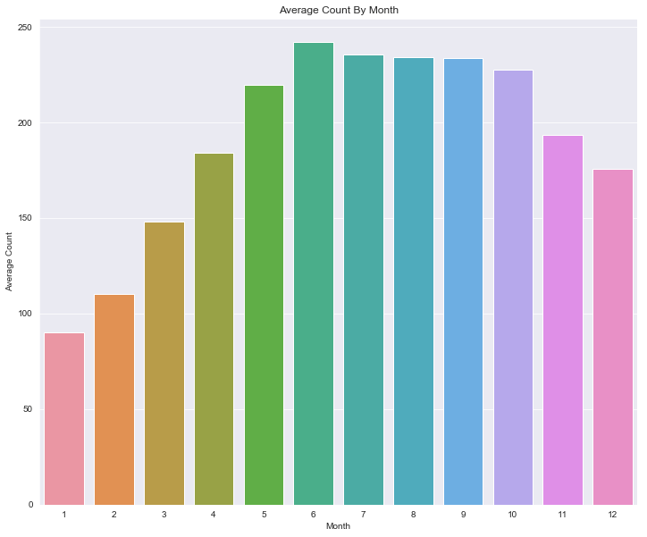

```python
fig,ax = plt.subplots()
fig.set_size_inches(12,10)

# monthLabels = ['January','Feburary','March','April','May','June','July','August','September','October','November','December']
byMonth = pd.DataFrame(df.groupby('month')['count'].mean()).reset_index()
sns.barplot(data=byMonth,x='month',y='count')
ax.set(xlabel='Month', ylabel='Average Count',title="Average Count By Month")
```

### Bivariate Plots

Next, we compare non-registered and registered rentals.

```python
df1 = df.groupby('weather')['casual'].sum()
df1 = df1.reset_index()
```

```python
df2 = df.groupby('weather')['registered'].sum()
df2 = df2.reset_index()
```

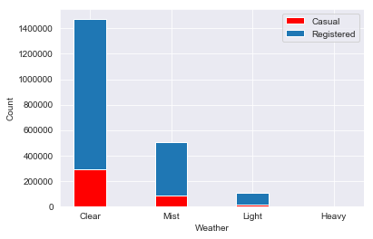

```python
# Easier to do stacked graphs in matlibplot than seaborn (albeit less aesthetic)
width = 0.4
p1 = plt.bar(df1['weather'],df1['casual'],width,color='r')
p2 = plt.bar(df2['weather'],df2['registered'],width,bottom=df1['casual'])
plt.xticks(df1['weather'],['Clear','Mist','Light','Heavy'])
plt.xlabel('Weather')
plt.ylabel('Count')
plt.legend(['Casual','Registered'])
plt.show()
```

There are more registered users than casual users. Most of the bikes were rented in Clear weather, and hardly any bikes were rented during Heavy weather.

[output not shown]

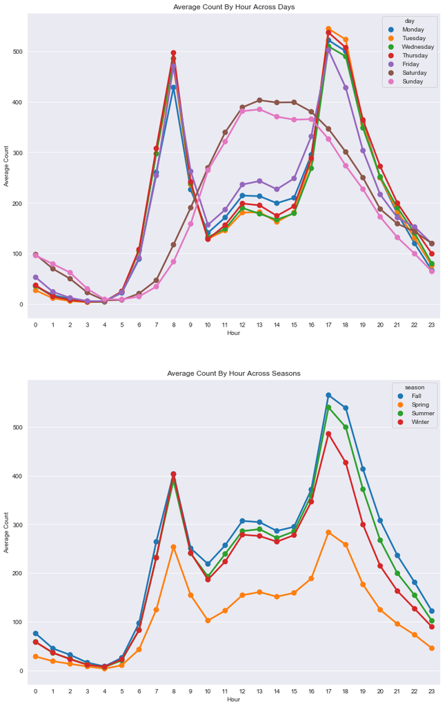

```python
fig,(ax1,ax2) = plt.subplots(nrows=2)
fig.set_size_inches(12,20)

dayLabels = ['Monday','Tuesday','Wednesday','Thursday','Friday','Saturday','Sunday']
byDays = pd.DataFrame(df.groupby(['hour','day'],sort=True)['count'].mean()).reset_index()
sns.pointplot(data=byDays, x='hour',y='count',hue=byDays['day'], hue_order = dayLabels, ax=ax1)
ax1.set(xlabel='Hour', ylabel='Average Count', title="Average Count By Hour Across Days")

bySeason = pd.DataFrame(df.groupby(['hour','season'],sort=True)['count'].mean()).reset_index()
sns.pointplot(data=bySeason,x='hour', y='count', hue=bySeason['season'],ax=ax2)
ax2.set(xlabel='Hour', ylabel='Average Count', title="Average Count By Hour Across Seasons")
```

### Removing Features

Based on the above, we will be removing these features:

- datetime (we already split it into its individual components)
- atemp
- windspeed
- casual
- registered

```python
df = df.drop(['datetime','atemp','windspeed','casual','registered'],axis=1)
```

[output not shown]

# Making Predictions

We will try a few different methods and assess them based on their accuracy on the RMSLE (lower is better).

### Preparing train and test data

We will need to create dummy variables for our categorical variables. These are:

- day
- hour
- month
- year
- season

```python
dummies = ['day','hour','month','year','season']
final_df = pd.get_dummies(df, columns = dummies)
final_df.columns
```

```
Index(['holiday', 'workingday', 'weather', 'temp', 'humidity', 'count',
       'day_Friday', 'day_Monday', 'day_Saturday', 'day_Sunday',
       'day_Thursday', 'day_Tuesday', 'day_Wednesday', 'hour_0', 'hour_1',
       'hour_2', 'hour_3', 'hour_4', 'hour_5', 'hour_6', 'hour_7', 'hour_8',
       'hour_9', 'hour_10', 'hour_11', 'hour_12', 'hour_13', 'hour_14',
       'hour_15', 'hour_16', 'hour_17', 'hour_18', 'hour_19', 'hour_20',
       'hour_21', 'hour_22', 'hour_23', 'month_1', 'month_2', 'month_3',
       'month_4', 'month_5', 'month_6', 'month_7', 'month_8', 'month_9',
       'month_10', 'month_11', 'month_12', 'year_2011', 'year_2012',
       'season_Fall', 'season_Spring', 'season_Summer', 'season_Winter'],
      dtype='object')
```

We repeat the earlier steps we took to prepare the train data for the test data.

```python
df_test = pd.read_csv("test.csv")
df_test['datetime'] = pd.to_datetime(df_test['datetime'])
df_time = pd.DataFrame({'year':df_test['datetime'].dt.year,'month':df_test['datetime'].dt.month,'day':df_test['datetime'].dt.weekday,'hour':df_test['datetime'].dt.hour})
df_test = pd.concat([df_time,df_test[['season','holiday','workingday','weather','temp','humidity']]], axis=1)

df_test['season'] = df_test.season.map({1: 'Spring', 2 : 'Summer', 3 : 'Fall', 4 :'Winter' })
df_test['day'] = df_test.day.map({0: 'Monday', 1: 'Tuesday', 2: 'Wednesday', 3: 'Thursday', 4: 'Friday', 5: 'Saturday', 6: 'Sunday'})

df_test = pd.get_dummies(df_test, columns = dummies)
df_test.head()
```

|  | holiday | workingday | weather | temp | humidity | day_Friday | day_Monday | day_Saturday | day_Sunday | day_Thursday | ... | month_9 | month_10 | month_11 | month_12 | year_2011 | year_2012 | season_Fall | season_Spring | season_Summer | season_Winter |
| --- | --- | --- | --- | --- | --- | --- | --- | --- | --- | --- | --- | --- | --- | --- | --- | --- | --- | --- | --- | --- | --- |
| 0 | 0 | 1 | 1 | 10.66 | 56 | 0 | 0 | 0 | 0 | 1 | ... | 0 | 0 | 0 | 0 | 1 | 0 | 0 | 1 | 0 | 0 |
| 1 | 0 | 1 | 1 | 10.66 | 56 | 0 | 0 | 0 | 0 | 1 | ... | 0 | 0 | 0 | 0 | 1 | 0 | 0 | 1 | 0 | 0 |
| 2 | 0 | 1 | 1 | 10.66 | 56 | 0 | 0 | 0 | 0 | 1 | ... | 0 | 0 | 0 | 0 | 1 | 0 | 0 | 1 | 0 | 0 |
| 3 | 0 | 1 | 1 | 10.66 | 56 | 0 | 0 | 0 | 0 | 1 | ... | 0 | 0 | 0 | 0 | 1 | 0 | 0 | 1 | 0 | 0 |
| 4 | 0 | 1 | 1 | 10.66 | 56 | 0 | 0 | 0 | 0 | 1 | ... | 0 | 0 | 0 | 0 | 1 | 0 | 0 | 1 | 0 | 0 |

5 rows × 54 columns

```python
df_test.columns
```

```
Index(['holiday', 'workingday', 'weather', 'temp', 'humidity', 'day_Friday',
       'day_Monday', 'day_Saturday', 'day_Sunday', 'day_Thursday',
       'day_Tuesday', 'day_Wednesday', 'hour_0', 'hour_1', 'hour_2', 'hour_3',
       'hour_4', 'hour_5', 'hour_6', 'hour_7', 'hour_8', 'hour_9', 'hour_10',
       'hour_11', 'hour_12', 'hour_13', 'hour_14', 'hour_15', 'hour_16',
       'hour_17', 'hour_18', 'hour_19', 'hour_20', 'hour_21', 'hour_22',
       'hour_23', 'month_1', 'month_2', 'month_3', 'month_4', 'month_5',
       'month_6', 'month_7', 'month_8', 'month_9', 'month_10', 'month_11',
       'month_12', 'year_2011', 'year_2012', 'season_Fall', 'season_Spring',
       'season_Summer', 'season_Winter'],
      dtype='object')
```

### Linear Regression Model

```python
from sklearn.linear_model import LinearRegression
lmodel = LinearRegression()
lmodel.fit(final_df.drop(['count'],axis=1),final_df['count'].apply(np.log))
```

```
LinearRegression(copy_X=True, fit_intercept=True, n_jobs=None,
         normalize=False)
```

To evaluate our model, we will use root mean squared logarithmic error.

```python
def rmsle(y1, y2):
    log1 = np.array([np.log(v + 1) for v in y1])
    log2 = np.array([np.log(v + 1) for v in y2])
    calc = (log1 - log2) ** 2
    return np.sqrt(np.mean(calc))
```

```python
preds = lmodel.predict(final_df.drop(['count'],axis=1))
print ("RMSLE Value For Linear Regression: ",rmsle(final_df['count'],np.exp(preds)))
```

[output not shown]

Predicting for test data:

```python
preds_sub = lmodel.predict(df_test)
preds_sub = np.exp(preds_sub)
preds_sub
```

```
array([ 17.46660072,   8.84192307,   3.81146144, ..., 111.80953854,
        88.31376603,  54.31562896])
```

For submission:

```python
preds_sub = pd.Series(preds_sub)
df_test2 = pd.read_csv('test.csv')
df_sub = df_test2['datetime']
df_sub = df_sub.to_frame().join(preds_sub.to_frame())
df_sub.columns = ['datetime','count']
```

```python
df_sub.to_csv('submission_lr.csv',index = False)
```

The submission scored 0.66405.

### Ridge Regression

```python
from sklearn.linear_model import Ridge
for alpha in [0.001,0.01,0.1,1.0,10]:
    rmodel = Ridge(alpha)
    rmodel.fit(final_df.drop(['count'],axis=1),final_df['count'].apply(np.log))
    preds = rmodel.predict(final_df.drop(['count'],axis=1))
    print ("RMSLE Value For Ridge Regression for alpha {:f}: {:f}".format(alpha,rmsle(final_df['count'],np.exp(preds))))
```

[output not shown]

```python
rmodel = Ridge(alpha = 1)
rmodel.fit(final_df.drop(['count'],axis=1),final_df['count'].apply(np.log))
preds_sub = rmodel.predict(df_test)
preds_sub = np.exp(preds_sub)
preds_sub
```

```
array([ 16.14050617,   8.42520557,   4.84714386, ..., 111.68234695,
        88.28298581,  57.88092268])
```

For submission:

```python
preds_sub = pd.Series(preds_sub)
df_test2 = pd.read_csv('test.csv')
df_sub = df_test2['datetime']
df_sub = df_sub.to_frame().join(preds_sub.to_frame())
df_sub.columns = ['datetime','count']
```

```python
df_sub.to_csv('submission_rr.csv',index = False)
```

This submission scored 0.62598.

### Lasso Regression

```python
from sklearn.linear_model import Lasso
for alpha in [0.001,0.01,0.1,1.0,10]:
    lasmodel = Lasso(alpha=0.1)
    lasmodel.fit(final_df.drop(['count'],axis=1),final_df['count'].apply(np.log))
    preds = lasmodel.predict(final_df.drop(['count'],axis=1))
    print ("RMSLE Value For Lasso Regression for alpha {:f}: {:f}".format(alpha,rmsle(final_df['count'],np.exp(preds))))
```

[output not shown]

```python
lasmodel = Lasso(alpha = 1)
preds_sub = lasmodel.predict(df_test)
preds_sub = np.exp(preds_sub)
preds_sub
```

[output not shown]

For submission:

```python
preds_sub = pd.Series(preds_sub)
df_test2 = pd.read_csv('test.csv')
df_sub = df_test2['datetime']
df_sub = df_sub.to_frame().join(preds_sub.to_frame())
df_sub.columns = ['datetime','count']
```

```python
df_sub.to_csv('submission_lasr.csv',index = False)
```

This submission scored 0.63225.

### Random Forest Regression

```python
from sklearn.ensemble import RandomForestRegressor
rfmodel = RandomForestRegressor(n_estimators=100)
rfmodel.fit(final_df.drop(['count'],axis=1),final_df['count'].apply(np.log))
preds = rfmodel.predict(final_df.drop(['count'],axis=1))
print ("RMSLE Value For Random Forest: ",rmsle(final_df['count'],np.exp(preds)))
```

```
RMSLE Value For Random Forest:  0.11967762067516508
```

```python
feature_importances = pd.DataFrame(rfmodel.feature_importances_,
                                   index = final_df.drop(['count'],axis=1).columns,
                                    columns=['importance']).sort_values('importance',ascending=False)
feature_importances
```

|  | importance |
| --- | --- |
| hour_4 | 0.165373 |
| hour_3 | 0.141224 |
| hour_2 | 0.105644 |
| hour_5 | 0.097044 |
| temp | 0.078722 |
| hour_1 | 0.077570 |
| workingday | 0.074306 |
| hour_0 | 0.037057 |
| humidity | 0.026267 |
| hour_6 | 0.026010 |
| season_Spring | 0.016895 |
| hour_23 | 0.016386 |
| year_2011 | 0.014813 |
| year_2012 | 0.014692 |
| hour_7 | 0.011692 |
| weather | 0.011321 |
| hour_8 | 0.010053 |
| season_Winter | 0.007928 |
| hour_17 | 0.007857 |
| hour_18 | 0.006654 |
| hour_22 | 0.004816 |
| day_Friday | 0.003997 |
| day_Sunday | 0.003305 |
| hour_19 | 0.003060 |
| month_4 | 0.003005 |
| hour_9 | 0.002380 |
| hour_21 | 0.002216 |
| hour_20 | 0.002074 |
| day_Monday | 0.001959 |
| day_Saturday | 0.001947 |
| hour_10 | 0.001862 |
| hour_16 | 0.001807 |
| month_1 | 0.001792 |
| day_Wednesday | 0.001668 |
| holiday | 0.001398 |
| day_Thursday | 0.001344 |
| day_Tuesday | 0.001258 |
| month_5 | 0.001212 |
| month_3 | 0.001211 |
| month_2 | 0.001059 |
| season_Summer | 0.000950 |
| month_10 | 0.000943 |
| month_9 | 0.000865 |
| hour_11 | 0.000839 |
| month_12 | 0.000793 |
| month_11 | 0.000731 |
| hour_12 | 0.000639 |
| season_Fall | 0.000609 |
| month_6 | 0.000524 |
| month_7 | 0.000509 |
| hour_14 | 0.000491 |
| hour_13 | 0.000437 |
| month_8 | 0.000401 |
| hour_15 | 0.000389 |

Predicting for test data:

```python
preds_sub = rfmodel.predict(df_test)
preds_sub = np.exp(preds_sub)
preds_sub
```

```
array([ 10.36814641,   3.0752158 ,   2.76253182, ..., 112.11442166,
        93.59222268,  55.35118974])
```

For submission:

```python
preds_sub = pd.Series(preds_sub)
df_test2 = pd.read_csv('test.csv')
df_sub = df_test2['datetime']
df_sub = df_sub.to_frame().join(preds_sub.to_frame())
df_sub.columns = ['datetime','count']
```

```python
df_sub.to_csv('submission_rf.csv',index = False)
```

This submission scored 0.41089.

### Boosting

```python
cat_columns = final_df.select_dtypes(['category']).columns
final_df[cat_columns] = final_df[cat_columns].apply(lambda x: x.cat.codes)
```

```python
import xgboost as xgb
xg_reg = xgb.XGBRegressor(objective ='reg:linear', colsample_bytree = 0.3, learning_rate = 0.1,
                max_depth = 5, alpha = 10, n_estimators = 100)
xg_reg.fit(final_df.drop(['count'],axis=1),final_df['count'].apply(np.log))
```

```
XGBRegressor(alpha=10, base_score=0.5, booster='gbtree', colsample_bylevel=1,
       colsample_bytree=0.3, gamma=0, importance_type='gain',
       learning_rate=0.1, max_delta_step=0, max_depth=5,
       min_child_weight=1, missing=None, n_estimators=100, n_jobs=1,
       nthread=None, objective='reg:linear', random_state=0, reg_alpha=0,
       reg_lambda=1, scale_pos_weight=1, seed=None, silent=True,
       subsample=1)
```

```python
preds = xg_reg.predict(final_df.drop(['count'],axis=1))
print ("RMSLE Value For Boosting: ",rmsle(final_df['count'],np.exp(preds)))
```

```
RMSLE Value For Boosting:  0.3957384116281124
```

Predicting for test data:

```python
preds_sub = xg_reg.predict(df_test)
preds_sub = np.exp(preds_sub)
preds_sub
```

```
array([ 11.648093 ,   4.5127115,   3.4661877, ..., 114.09533  ,
        96.781136 ,  50.1189   ], dtype=float32)
```

For submission:

```python
preds_sub = pd.Series(preds_sub)
df_test2 = pd.read_csv('test.csv')
df_sub = df_test2['datetime']
df_sub = df_sub.to_frame().join(preds_sub.to_frame())
df_sub.columns = ['datetime','count']
```

```python
df_sub.to_csv('submission_boost.csv',index = False)
```